# The effect of dehorning and other potential factors influencing horn growth in game-ranched white rhinoceroses (Ceratotherium simum simum)

This is a notebook for the dehorning data of Ververs et al. (2018). When you execute code within the notebook, the results appear beneath the code.

## Data extraction, transformation and loading

This has a first larger dataset is loaded in memory to start from.

# Descriptive statistics

A summary is requested holding descriptive statistics.

## All sexes together

```r
summary(df.cv.final)
```

```
  GENDER         AH_W_G         PH_W_G        SHAVINGS_W_G       TOTAL
 F   :1297   Min.   :   5   Min.   :   2.0   Min.   :  6.0   Min.   :   5
 M   : 747   1st Qu.: 849   1st Qu.: 142.0   1st Qu.: 61.0   1st Qu.:1017
 NA's:   1   Median :1263   Median : 259.0   Median : 99.0   Median :1610
             Mean   :1339   Mean   : 308.9   Mean   :103.9   Mean   :1708
             3rd Qu.:1670   3rd Qu.: 406.0   3rd Qu.:139.0   3rd Qu.:2173
             Max.   :5900   Max.   :2336.0   Max.   :495.0   Max.   :8166
             NA's   :4      NA's   :216      NA's   :175
      AH_L            AH_C         AH_STUMP_L          PH_L
 Min.   : 15.0   Min.   : 55.0   Min.   : 10.00   Min.   :  5.0
 1st Qu.:119.0   1st Qu.:505.0   1st Qu.: 75.00   1st Qu.: 40.0
 Median :145.0   Median :590.0   Median : 80.00   Median : 50.0
 Mean   :168.8   Mean   :572.7   Mean   : 84.74   Mean   : 56.6
 3rd Qu.:185.0   3rd Qu.:645.0   3rd Qu.: 90.00   3rd Qu.: 65.0
 Max.   :835.0   Max.   :870.0   Max.   :145.00   Max.   :250.0
 NA's   :37      NA's   :90      NA's   :185      NA's   :222
      PH_C         PH_STUMP_L        CALC_AGE     CALC_ARRIVAL
 Min.   : 20.0   Min.   :  5.00   Min.   :  58   Min.   :-318.0
 1st Qu.:420.0   1st Qu.: 20.00   1st Qu.: 924   1st Qu.: 479.0
 Median :510.0   Median : 25.00   Median :1379   Median : 786.0
 Mean   :491.2   Mean   : 27.25   Mean   :1555   Mean   : 882.2
 3rd Qu.:575.0   3rd Qu.: 30.00   3rd Qu.:1967   3rd Qu.:1274.5
 Max.   :960.0   Max.   :100.00   Max.   :5909   Max.   :5468.0
 NA's   :129     NA's   :343      NA's   :956    NA's   :498
    DH_YEAR       DH_MONTH   DH_QUARTER     W_DIFF         L_DIFF
 2014   :548   11     :316   1:283      Min.   :-498   Min.   :-106.0
 2015   :531   9      :309   2:553      1st Qu.: 796   1st Qu.:  70.0
 2013   :340   5      :251   3:542      Median :1050   Median :  90.0
 2012   :319   6      :195   4:667      Mean   :1126   Mean   : 113.4
 2011   :252   12     :192              3rd Qu.:1335   3rd Qu.: 135.0
 2010   : 44   7      :167              Max.   :5313   Max.   : 630.0
 (Other): 11   (Other):615              NA's   :220    NA's   :226
     C_DIFF            B_YEAR       B_MONTH    B_QUARTER    DIM_DEHORN
 Min.   :-840.00   2010   :201   3      :169   1   :400   Min.   :   1.0
 1st Qu.:  50.00   2008   :191   4      :124   2   :313   1st Qu.: 285.8
 Median :  80.00   2011   :190   1      :116   3   :183   Median : 487.0
 Mean   :  85.44   2012   :137   6      :116   4   :193   Mean   : 546.3
 3rd Qu.: 120.00   2009   : 98   2      :115   NA's:956   3rd Qu.: 721.5
 Max.   : 608.00   (Other):272   (Other):449              Max.   :2070.0
 NA's   :134       NA's   :956   NA's   :956              NA's   :1449
```

[output cut: 17 more lines]

```
 Min.   : 0.0145   Min.   :  0.0731   Min.   : 0.0098   Min.   : 0.0073
 1st Qu.: 0.1728   1st Qu.:  0.5434   1st Qu.: 0.1119   1st Qu.: 0.0456
 Median : 0.2165   Median :  0.8126   Median : 0.3198   Median : 0.0669
 Mean   : 0.2515   Mean   :  1.0452   Mean   : 0.6213   Mean   : 0.0881
 3rd Qu.: 0.2612   3rd Qu.:  1.0843   3rd Qu.: 0.5513   3rd Qu.: 0.0900
 Max.   :18.3333   Max.   :111.6667   Max.   :86.3333   Max.   :10.0000
 NA's   :491       NA's   :522        NA's   :660       NA's   :659
     G_PH_C
 Min.   : 0.0195
 1st Qu.: 0.4062
 Median : 0.6739
 Mean   : 0.8797
 3rd Qu.: 0.9430
 Max.   :86.6667
 NA's   :550
```

```r
describe(df.cv.final)
```

```
              vars    n    mean     sd  median trimmed    mad     min
GENDER*          1 2044    1.37   0.48    1.00    1.33   0.00    1.00
AH_W_G           2 2041 1338.94 738.70 1263.00 1267.16 609.35    5.00
PH_W_G           3 1829  308.93 246.84  259.00  275.47 192.74    2.00
SHAVINGS_W_G     4 1870  103.89  57.64   99.00   99.87  57.82    6.00
TOTAL            5 2045 1707.62 984.53 1610.00 1616.93 856.94    5.00
AH_L             6 2008  168.81  91.64  145.00  151.88  51.89   15.00
AH_C             7 1955  572.67 108.74  590.00  578.41  96.37   55.00
AH_STUMP_L       8 1860   84.74  14.57   80.00   83.94  14.83   10.00
PH_L             9 1823   56.60  30.79   50.00   51.62  22.24    5.00
PH_C            10 1916  491.24 127.77  510.00  498.75 103.78   20.00
PH_STUMP_L      11 1702   27.25  10.09   25.00   26.70   7.41    5.00
CALC_AGE        12 1089 1554.74 839.96 1379.00 1452.76 748.71   58.00
CALC_ARRIVAL    13 1547  882.22 612.32  786.00  843.47 590.07 -318.00
DH_YEAR*        14 2045    4.34   1.45    5.00    4.44   1.48    1.00
DH_MONTH*       15 2045    7.48   3.22    8.00    7.64   4.45    1.00
DH_QUARTER*     16 2045    2.78   1.05    3.00    2.85   1.48    1.00
W_DIFF          17 1825 1125.98 514.80 1050.00 1067.21 398.82 -498.00
L_DIFF          18 1819  113.44  73.81   90.00  101.23  44.48 -106.00
C_DIFF          19 1911   85.44  62.89   80.00   84.73  59.30 -840.00
B_YEAR*         20 1089   10.55   2.49   11.00   10.76   2.97    1.00
B_MONTH*        21 1089    5.58   3.45    5.00    5.37   4.45    1.00
B_QUARTER*      22 1089    2.16   1.11    2.00    2.07   1.48    1.00
DIM_DEHORN      23  596  546.29 339.53  487.00  511.57 316.54    1.00
INT_DEHORN      24  985  589.93 206.17  587.00  587.22 195.70    0.00
CALC_PARITY*    25 2043    1.44   0.78    1.00    1.26   0.00    1.00
C_YEAR*         26  596    6.04   1.57    6.00    6.06   1.48    1.00
C_MONTH*        27  596    5.38   3.74    4.00    5.11   2.97    1.00
C_QUARTER*      28  596    1.99   1.04    2.00    1.86   1.48    1.00
N_DEHORNINGS*   29 2043    1.68   0.82    1.00    1.56   0.00    1.00
GR_DAYS         30 1582  832.91 602.41  692.00  722.57 269.83    0.00
G_TOTAL         31 1580    3.09  11.76    2.15    2.13   1.75    0.01
G_AH_W          32 1576    2.39   8.69    1.71    1.69   1.27    0.01
G_AH_L          33 1554    0.25   0.58    0.22    0.22   0.07    0.01
G_AH_C          34 1523    1.05   4.00    0.81    0.82   0.40    0.07
G_PH_W          35 1385    0.62   2.86    0.32    0.35   0.32    0.01
G_PH_L          36 1386    0.09   0.31    0.07    0.07   0.03    0.01
G_PH_C          37 1495    0.88   3.22    0.67    0.69   0.40    0.02
                  max   range  skew kurtosis    se
GENDER*          2.00    1.00  0.56    -1.69  0.01
```

[output cut: 21 more lines]

```
DIM_DEHORN    2070.00 2069.00  1.05     1.38 13.91
INT_DEHORN    1335.00 1335.00  0.12     0.74  6.57
CALC_PARITY*     5.00    4.00  1.79     2.65  0.02
C_YEAR*          9.00    8.00 -0.13    -0.55  0.06
C_MONTH*        12.00   11.00  0.60    -1.11  0.15
C_QUARTER*       4.00    3.00  0.61    -0.91  0.04
N_DEHORNINGS*    5.00    4.00  1.02     0.42  0.02
GR_DAYS       4892.00 4892.00  2.98    11.58 15.15
G_TOTAL        332.67  332.66 24.17   638.75  0.30
G_AH_W         246.33  246.32 24.25   641.86  0.22
G_AH_L          18.33   18.32 25.62   727.69  0.01
G_AH_C         111.67  111.59 26.06   700.90  0.10
G_PH_W          86.33   86.32 23.35   638.99  0.08
G_PH_L          10.00    9.99 26.54   788.65  0.01
G_PH_C          86.67   86.65 25.43   672.70  0.08
```

## Males

```r
summary(df.cv.final[df.cv.final$GENDER == "M", ])
```

```
  GENDER        AH_W_G           PH_W_G        SHAVINGS_W_G       TOTAL
 F   :  0   Min.   :  18.0   Min.   :   8.0   Min.   :  6.0   Min.   :  18
 M   :747   1st Qu.: 853.5   1st Qu.: 101.8   1st Qu.: 55.0   1st Qu.:1000
 NA's:  1   Median :1302.0   Median : 263.0   Median :100.0   Median :1675
            Mean   :1400.5   Mean   : 329.9   Mean   :108.8   Mean   :1802
            3rd Qu.:1788.5   3rd Qu.: 468.8   3rd Qu.:148.0   3rd Qu.:2361
            Max.   :5830.0   Max.   :2336.0   Max.   :372.0   Max.   :8166
            NA's   :1        NA's   :70       NA's   :47      NA's   :1
      AH_L          AH_C         AH_STUMP_L          PH_L
 Min.   : 15   Min.   : 80.0   Min.   : 35.00   Min.   : 10.00
 1st Qu.:120   1st Qu.:496.2   1st Qu.: 80.00   1st Qu.: 38.75
 Median :160   Median :575.0   Median : 85.00   Median : 50.00
 Mean   :174   Mean   :580.0   Mean   : 89.57   Mean   : 54.53
 3rd Qu.:200   3rd Qu.:680.0   3rd Qu.:100.00   3rd Qu.: 65.00
 Max.   :600   Max.   :870.0   Max.   :145.00   Max.   :235.00
 NA's   :7     NA's   :26      NA's   :49       NA's   :72
      PH_C         PH_STUMP_L        CALC_AGE     CALC_ARRIVAL
 Min.   : 20.0   Min.   :  5.00   Min.   :  58   Min.   :   0.0
 1st Qu.:400.0   1st Qu.: 20.00   1st Qu.: 928   1st Qu.: 418.8
 Median :540.0   Median : 30.00   Median :1406   Median : 745.5
 Mean   :519.5   Mean   : 28.29   Mean   :1576   Mean   : 820.7
 3rd Qu.:636.2   3rd Qu.: 35.00   3rd Qu.:2053   3rd Qu.:1169.8
 Max.   :800.0   Max.   :100.00   Max.   :5468   Max.   :5468.0
 NA's   :36      NA's   :105      NA's   :160    NA's   :246
    DH_YEAR       DH_MONTH   DH_QUARTER     W_DIFF           L_DIFF
 2014   :206   11     :128   1   :113   Min.   :-498.0   Min.   :-65.0
 2015   :196   9      :108   2   :175   1st Qu.: 825.2   1st Qu.: 75.0
 2012   :120   6      : 84   3   :193   Median :1083.5   Median :110.0
 2013   :112   12     : 84   4   :266   Mean   :1158.8   Mean   :122.2
 2011   : 84   5      : 68   NA's:  1   3rd Qu.:1400.0   3rd Qu.:156.2
 (Other): 29   (Other):275              Max.   :3709.0   Max.   :418.0
 NA's   :  1   NA's   :  1              NA's   :70       NA's   :72
     C_DIFF            B_YEAR       B_MONTH    B_QUARTER    DIM_DEHORN
 Min.   :-140.00   2008   :133   3      : 84   1   :176   Min.   : 86
 1st Qu.:  20.00   2011   : 90   4      : 67   2   :177   1st Qu.:137
 Median :  60.00   2010   : 81   9      : 66   3   :135   Median :188
 Mean   :  64.03   2012   : 71   1      : 62   4   :100   Mean   :188
 3rd Qu.: 100.00   2009   : 53   6      : 61   NA's:160   3rd Qu.:239
 Max.   : 409.00   (Other):160   (Other):248              Max.   :290
 NA's   :37        NA's   :160   NA's   :160              NA's   :746
```

[output cut: 17 more lines]

```
 Min.   :0.02181   Min.   : 0.0779   Min.   : 0.01020   Min.   :0.00860
 1st Qu.:0.19410   1st Qu.: 0.5202   1st Qu.: 0.08737   1st Qu.:0.04320
 Median :0.23309   Median : 0.7977   Median : 0.32456   Median :0.06807
 Mean   :0.24009   Mean   : 0.9128   Mean   : 0.53851   Mean   :0.07710
 3rd Qu.:0.26881   3rd Qu.: 1.1688   3rd Qu.: 0.69767   3rd Qu.:0.09511
 Max.   :2.71429   Max.   :13.2857   Max.   :11.18919   Max.   :1.28571
 NA's   :86        NA's   :101       NA's   :147        NA's   :148
     G_PH_C
 Min.   : 0.01947
 1st Qu.: 0.41370
 Median : 0.68516
 Mean   : 0.81241
 3rd Qu.: 1.07997
 Max.   :13.14286
 NA's   :110
```

```r
describe(df.cv.final[df.cv.final$GENDER == "M", ])
```

```
              vars   n    mean      sd  median trimmed     mad     min
GENDER*          1 747    2.00    0.00    2.00    2.00    0.00    2.00
AH_W_G           2 747 1400.51  776.26 1302.00 1323.66  687.93   18.00
PH_W_G           3 678  329.86  300.33  263.00  285.08  261.68    8.00
SHAVINGS_W_G     4 701  108.82   66.53  100.00  102.62   69.68    6.00
TOTAL            5 747 1802.02 1089.14 1675.00 1689.71 1005.20   18.00
AH_L             6 741  174.02   75.46  160.00  164.05   59.30   15.00
AH_C             7 722  580.01  124.90  575.00  582.18  140.85   80.00
AH_STUMP_L       8 699   89.57   17.11   85.00   88.68   14.83   35.00
PH_L             9 676   54.53   27.73   50.00   50.59   22.24   10.00
PH_C            10 712  519.45  144.12  540.00  527.10  163.09   20.00
PH_STUMP_L      11 643   28.29   11.02   30.00   27.57   14.83    5.00
CALC_AGE        12 588 1576.42  812.36 1405.50 1494.02  779.85   58.00
CALC_ARRIVAL    13 502  820.66  627.11  745.50  766.32  571.54    0.00
DH_YEAR*        14 747    4.37    1.47    5.00    4.48    1.48    1.00
DH_MONTH*       15 747    7.66    3.30    9.00    7.86    2.97    1.00
DH_QUARTER*     16 747    2.82    1.08    3.00    2.90    1.48    1.00
W_DIFF          17 678 1158.75  507.86 1083.50 1105.41  414.39 -498.00
L_DIFF          18 676  122.24   62.78  110.00  114.97   59.30  -65.00
C_DIFF          19 711   64.03   63.31   60.00   61.80   59.30 -140.00
B_YEAR*         20 588   10.31    2.51   11.00   10.46    2.97    2.00
B_MONTH*        21 588    5.93    3.36    6.00    5.82    4.45    1.00
B_QUARTER*      22 588    2.27    1.07    2.00    2.21    1.48    1.00
DIM_DEHORN      23   2  188.00  144.25  188.00  188.00  151.23   86.00
INT_DEHORN      24 354  544.23  161.20  560.00  546.75  158.64   35.00
CALC_PARITY*    25 745    1.00    0.08    1.00    1.00    0.00    1.00
C_YEAR*         26   2    6.00    1.41    6.00    6.00    1.48    5.00
C_MONTH*        27   2    2.50    0.71    2.50    2.50    0.74    2.00
C_QUARTER*      28   2    1.00    0.00    1.00    1.00    0.00    1.00
N_DEHORNINGS*   29 745    1.70    0.86    1.00    1.57    0.00    1.00
GR_DAYS         30 667  849.48  596.98  672.00  736.92  295.04   35.00
G_TOTAL         31 667    2.79    3.21    2.10    2.31    1.85    0.21
G_AH_W          32 667    2.15    2.31    1.69    1.82    1.34    0.21
G_AH_L          33 662    0.24    0.15    0.23    0.23    0.06    0.02
G_AH_C          34 647    0.91    0.70    0.80    0.84    0.46    0.08
G_PH_W          35 601    0.54    0.92    0.32    0.38    0.38    0.01
G_PH_L          36 600    0.08    0.07    0.07    0.07    0.04    0.01
G_PH_C          37 638    0.81    0.69    0.69    0.74    0.46    0.02
                  max   range  skew kurtosis     se
GENDER*          2.00    0.00   NaN      NaN   0.00
```

[output cut: 21 more lines]

```
DIM_DEHORN     290.00  204.00  0.00    -2.75 102.00
INT_DEHORN    1267.00 1232.00 -0.05     1.12   8.57
CALC_PARITY*     3.00    2.00 21.86   500.38   0.00
C_YEAR*          7.00    2.00  0.00    -2.75   1.00
C_MONTH*         3.00    1.00  0.00    -2.75   0.50
C_QUARTER*       1.00    0.00   NaN      NaN   0.00
N_DEHORNINGS*    5.00    4.00  1.05     0.34   0.03
GR_DAYS       4697.00 4662.00  2.51     7.76  23.12
G_TOTAL         39.57   39.35  5.68    48.78   0.12
G_AH_W          28.38   28.16  5.74    49.77   0.09
G_AH_L           2.71    2.69  9.67   133.84   0.01
G_AH_C          13.29   13.21  8.87   146.69   0.03
G_PH_W          11.19   11.18  6.48    56.82   0.04
G_PH_L           1.29    1.28  9.69   135.22   0.00
G_PH_C          13.14   13.12  9.31   155.91   0.03
```

## Females

```r
summary(df.cv.final[df.cv.final$GENDER == "F", ])
```

```
  GENDER         AH_W_G         PH_W_G        SHAVINGS_W_G       TOTAL
 F   :1297   Min.   :   5   Min.   :   2.0   Min.   : 10.0   Min.   :   5
 M   :   0   1st Qu.: 845   1st Qu.: 156.0   1st Qu.: 65.0   1st Qu.:1038
 NA's:   1   Median :1242   Median : 257.0   Median : 99.0   Median :1594
             Mean   :1304   Mean   : 296.6   Mean   :100.9   Mean   :1655
             3rd Qu.:1593   3rd Qu.: 386.5   3rd Qu.:133.0   3rd Qu.:2089
             Max.   :5900   Max.   :1348.0   Max.   :495.0   Max.   :6696
             NA's   :5      NA's   :147      NA's   :129     NA's   :1
      AH_L            AH_C         AH_STUMP_L          PH_L
 Min.   : 20.0   Min.   : 55.0   Min.   : 10.00   Min.   :  5.00
 1st Qu.:110.0   1st Qu.:515.0   1st Qu.: 75.00   1st Qu.: 40.00
 Median :140.0   Median :600.0   Median : 80.00   Median : 50.00
 Mean   :165.8   Mean   :568.4   Mean   : 81.84   Mean   : 57.82
 3rd Qu.:175.0   3rd Qu.:635.0   3rd Qu.: 90.00   3rd Qu.: 65.00
 Max.   :835.0   Max.   :780.0   Max.   :130.00   Max.   :250.00
 NA's   :31      NA's   :65      NA's   :137      NA's   :151
      PH_C         PH_STUMP_L       CALC_AGE     CALC_ARRIVAL
 Min.   : 30.0   Min.   :10.00   Min.   :  94   Min.   :-318.0
 1st Qu.:423.8   1st Qu.:20.00   1st Qu.: 896   1st Qu.: 517.0
 Median :500.0   Median :25.00   Median :1349   Median : 824.0
 Mean   :474.5   Mean   :26.62   Mean   :1529   Mean   : 911.8
 3rd Qu.:550.0   3rd Qu.:30.00   3rd Qu.:1880   3rd Qu.:1331.0
 Max.   :960.0   Max.   :80.00   Max.   :5909   Max.   :2636.0
 NA's   :94      NA's   :239     NA's   :797    NA's   :253
    DH_YEAR       DH_MONTH   DH_QUARTER     W_DIFF           L_DIFF
 2014   :341   9      :201   1   :170   Min.   :  83.0   Min.   :-106.0
 2015   :335   11     :188   2   :377   1st Qu.: 779.5   1st Qu.:  65.0
 2013   :228   5      :183   3   :349   Median :1023.0   Median :  85.0
 2012   :199   6      :111   4   :401   Mean   :1106.6   Mean   : 108.2
 2011   :168   12     :108   NA's:  1   3rd Qu.:1301.0   3rd Qu.: 120.0
 (Other): 26   (Other):506              Max.   :5313.0   Max.   : 630.0
 NA's   :  1   NA's   :  1              NA's   :151      NA's   :155
     C_DIFF            B_YEAR       B_MONTH    B_QUARTER    DIM_DEHORN
 Min.   :-840.00   2010   :120   2      : 85   1   :224   Min.   :   1.0
 1st Qu.:  60.00   2011   :100   3      : 85   2   :136   1st Qu.: 286.0
 Median :  95.00   2012   : 66   4      : 57   3   : 48   Median : 487.0
 Mean   :  98.12   2008   : 58   6      : 55   4   : 93   Mean   : 547.5
 3rd Qu.: 130.00   2009   : 45   1      : 54   NA's:797   3rd Qu.: 722.5
 Max.   : 608.00   (Other):112   (Other):165              Max.   :2070.0
 NA's   :98        NA's   :797   NA's   :797              NA's   :704
```

[output cut: 17 more lines]

```
 Min.   : 0.0145   Min.   :  0.0731   Min.   : 0.0098   Min.   : 0.0073
 1st Qu.: 0.1623   1st Qu.:  0.5595   1st Qu.: 0.1364   1st Qu.: 0.0472
 Median : 0.2004   Median :  0.8206   Median : 0.3166   Median : 0.0660
 Mean   : 0.2601   Mean   :  1.1430   Mean   : 0.6847   Mean   : 0.0964
 3rd Qu.: 0.2493   3rd Qu.:  1.0250   3rd Qu.: 0.4729   3rd Qu.: 0.0849
 Max.   :18.3333   Max.   :111.6667   Max.   :86.3333   Max.   :10.0000
 NA's   :406       NA's   :422        NA's   :514       NA's   :512
     G_PH_C
 Min.   : 0.0274
 1st Qu.: 0.3927
 Median : 0.6723
 Mean   : 0.9298
 3rd Qu.: 0.8602
 Max.   :86.6667
 NA's   :441
```

```r
describe(df.cv.final[df.cv.final$GENDER == "F", ])
```

```
              vars    n    mean     sd  median trimmed    mad     min
GENDER*          1 1297    1.00   0.00    1.00    1.00   0.00    1.00
AH_W_G           2 1293 1304.37 713.42 1242.00 1236.49 551.53    5.00
PH_W_G           3 1151  296.61 208.19  257.00  271.27 163.09    2.00
SHAVINGS_W_G     4 1169  100.93  51.38   99.00   98.91  50.41   10.00
TOTAL            5 1297 1654.54 914.23 1594.00 1580.59 779.85    5.00
AH_L             6 1267  165.77  99.80  140.00  144.77  44.48   20.00
AH_C             7 1233  568.38  97.85  600.00  579.56  74.13   55.00
AH_STUMP_L       8 1161   81.84  11.90   80.00   81.87  14.83   10.00
PH_L             9 1147   57.82  32.40   50.00   52.25  14.83    5.00
PH_C            10 1204  474.55 113.84  500.00  487.80  88.96   30.00
PH_STUMP_L      11 1059   26.62   9.44   25.00   26.17   7.41   10.00
CALC_AGE        12  501 1529.31 871.36 1349.00 1404.41 722.03   94.00
CALC_ARRIVAL    13 1045  911.79 603.16  824.00  881.29 598.97 -318.00
DH_YEAR*        14 1297    4.32   1.43    5.00    4.42   1.48    1.00
DH_MONTH*       15 1297    7.39   3.17    7.00    7.52   4.45    1.00
DH_QUARTER*     16 1297    2.76   1.03    3.00    2.82   1.48    1.00
W_DIFF          17 1147 1106.60 518.11 1023.00 1044.93 382.51   83.00
L_DIFF          18 1143  108.24  79.19   85.00   93.02  37.06 -106.00
C_DIFF          19 1200   98.12  59.12   95.00   96.78  51.89 -840.00
B_YEAR*         20  501   10.83   2.45   11.00   11.10   1.48    1.00
B_MONTH*        21  501    5.16   3.52    4.00    4.83   2.97    1.00
B_QUARTER*      22  501    2.02   1.13    2.00    1.90   1.48    1.00
DIM_DEHORN      23  594  547.50 339.41  487.00  512.77 316.54    1.00
INT_DEHORN      24  631  615.57 223.60  616.00  614.64 212.01    0.00
CALC_PARITY*    25 1297    1.69   0.88    1.00    1.55   0.00    1.00
C_YEAR*         26  594    6.04   1.57    6.00    6.06   1.48    1.00
C_MONTH*        27  594    5.39   3.74    4.00    5.12   2.97    1.00
C_QUARTER*      28  594    1.99   1.04    2.00    1.87   1.48    1.00
N_DEHORNINGS*   29 1297    1.66   0.79    1.00    1.55   0.00    1.00
GR_DAYS         30  915  820.83 606.38  702.00  714.67 259.45    0.00
G_TOTAL         31  913    3.31  15.23    2.17    2.02   1.52    0.01
G_AH_W          32  909    2.57  11.27    1.71    1.62   1.09    0.01
G_AH_L          33  892    0.26   0.76    0.20    0.21   0.06    0.01
G_AH_C          34  876    1.14   5.24    0.82    0.81   0.34    0.07
G_PH_W          35  784    0.68   3.72    0.32    0.32   0.24    0.01
G_PH_L          36  786    0.10   0.41    0.07    0.07   0.03    0.01
G_PH_C          37  857    0.93   4.21    0.67    0.66   0.34    0.03
                  max   range  skew kurtosis    se
GENDER*          1.00    0.00   NaN      NaN  0.00
```

[output cut: 21 more lines]

```
DIM_DEHORN    2070.00 2069.00  1.05     1.38 13.93
INT_DEHORN    1335.00 1335.00 -0.01     0.44  8.90
CALC_PARITY*     5.00    4.00  1.13     0.56  0.02
C_YEAR*          9.00    8.00 -0.13    -0.55  0.06
C_MONTH*        12.00   11.00  0.59    -1.12  0.15
C_QUARTER*       4.00    3.00  0.61    -0.91  0.04
N_DEHORNINGS*    5.00    4.00  0.99     0.41  0.02
GR_DAYS       4892.00 4892.00  3.31    14.26 20.05
G_TOTAL        332.67  332.66 19.20   391.14  0.50
G_AH_W         246.33  246.32 19.20   391.03  0.37
G_AH_L          18.33   18.32 20.22   441.43  0.03
G_AH_C         111.67  111.59 20.10   411.45  0.18
G_PH_W          86.33   86.32 18.69   393.65  0.13
G_PH_L          10.00    9.99 20.66   467.61  0.01
G_PH_C          86.67   86.64 19.77   398.97  0.14
```

## Only first dehoring descriptives

```r
summary(df.cv.final[df.cv.final$N_DEHORNINGS == "1", ])
```

```
  GENDER        AH_W_G           PH_W_G        SHAVINGS_W_G
 F   :666   Min.   :  12.0   Min.   :   2.0   Min.   :  6.00
 M   :391   1st Qu.: 667.2   1st Qu.:  69.0   1st Qu.: 40.00
 NA's:  3   Median :1075.5   Median : 246.0   Median : 75.00
            Mean   :1243.8   Mean   : 287.7   Mean   : 85.23
            3rd Qu.:1578.2   3rd Qu.: 408.0   3rd Qu.:118.00
            Max.   :5900.0   Max.   :2336.0   Max.   :495.00
            NA's   :4        NA's   :191      NA's   :82
     TOTAL           AH_L            AH_C         AH_STUMP_L
 Min.   :  12   Min.   : 15.0   Min.   : 55.0   Min.   : 10.00
 1st Qu.: 740   1st Qu.:135.0   1st Qu.:470.0   1st Qu.: 75.00
 Median :1330   Median :170.0   Median :550.0   Median : 80.00
 Mean   :1557   Mean   :202.6   Mean   :544.5   Mean   : 80.83
 3rd Qu.:2067   3rd Qu.:230.0   3rd Qu.:630.0   3rd Qu.: 90.00
 Max.   :8166   Max.   :835.0   Max.   :870.0   Max.   :140.00
 NA's   :2      NA's   :20      NA's   :59      NA's   :91
      PH_L             PH_C         PH_STUMP_L        CALC_AGE
 Min.   :  5.00   Min.   : 20.0   Min.   :  5.00   Min.   :  58
 1st Qu.: 40.00   1st Qu.:360.0   1st Qu.: 20.00   1st Qu.: 760
 Median : 55.00   Median :495.0   Median : 25.00   Median : 966
 Mean   : 65.54   Mean   :461.9   Mean   : 25.51   Mean   :1234
 3rd Qu.: 80.00   3rd Qu.:560.0   3rd Qu.: 30.00   3rd Qu.:1415
 Max.   :250.00   Max.   :960.0   Max.   :100.00   Max.   :4892
 NA's   :198      NA's   :98      NA's   :243      NA's   :463
  CALC_ARRIVAL        DH_YEAR       DH_MONTH   DH_QUARTER     W_DIFF
 Min.   :-318.00   2014   :250   11     :211   1   :141   Min.   :-498
 1st Qu.:  66.75   2011   :236   9      :164   2   :236   1st Qu.: 722
 Median : 520.00   2012   :197   5      :116   3   :290   Median : 954
 Mean   : 489.74   2015   :168   10     : 93   4   :391   Mean   :1107
 3rd Qu.: 760.50   2013   :162   12     : 87   NA's:  2   3rd Qu.:1324
 Max.   :4697.00   (Other): 45   (Other):387              Max.   :5313
 NA's   :314       NA's   :  2   NA's   :  2              NA's   :193
     L_DIFF           C_DIFF            B_YEAR       B_MONTH    B_QUARTER
 Min.   :-106.0   Min.   :-840.00   2011   :109   3      : 90   1   :228
 1st Qu.:  80.0   1st Qu.:  50.00   2012   :102   4      : 70   2   :159
 Median : 130.0   Median :  90.00   2013   : 88   1      : 69   3   : 91
 Mean   : 145.9   Mean   :  89.59   2010   : 86   2      : 69   4   :119
 3rd Qu.: 190.0   3rd Qu.: 127.00   2008   : 66   12     : 56   NA's:463
 Max.   : 630.0   Max.   : 300.00   (Other):146   (Other):243
 NA's   :200      NA's   :101       NA's   :463   NA's   :463
```

[output cut: 17 more lines]

```
 Min.   :0.0145   Min.   :0.0731   Min.   :0.0098   Min.   :0.0073
 1st Qu.:0.1476   1st Qu.:0.3517   1st Qu.:0.0364   1st Qu.:0.0257
 Median :0.2020   Median :0.4867   Median :0.0648   Median :0.0359
 Mean   :0.1920   Mean   :0.4823   Mean   :0.0927   Mean   :0.0390
 3rd Qu.:0.2369   3rd Qu.:0.5797   3rd Qu.:0.1154   3rd Qu.:0.0488
 Max.   :0.5714   Max.   :1.6489   Max.   :0.9409   Max.   :0.1117
 NA's   :470      NA's   :487      NA's   :631      NA's   :631
     G_PH_C
 Min.   :0.0195
 1st Qu.:0.2676
 Median :0.3463
 Mean   :0.3578
 3rd Qu.:0.4440
 Max.   :1.2381
 NA's   :515
```

```r
describe(df.cv.final[df.cv.final$N_DEHORNINGS == "1", ])
```

```
no non-missing arguments to min; returning Infno non-missing arguments to max; returning -Inf
```

```
              vars    n    mean      sd  median trimmed    mad     min
GENDER*          1 1057    1.37    0.48    1.00    1.34   0.00    1.00
AH_W_G           2 1056 1243.84  849.85 1075.50 1123.93 655.31   12.00
PH_W_G           3  869  287.70  261.93  246.00  249.70 255.01    2.00
SHAVINGS_W_G     4  978   85.23   58.54   75.00   78.42  57.82    6.00
TOTAL            5 1058 1556.58 1110.01 1330.50 1405.26 962.21   12.00
AH_L             6 1040  202.61  112.72  170.00  182.58  59.30   15.00
AH_C             7 1001  544.46  117.93  550.00  550.06 118.61   55.00
AH_STUMP_L       8  969   80.83   12.49   80.00   80.69   7.41   10.00
PH_L             9  862   65.54   39.50   55.00   59.29  29.65    5.00
PH_C            10  962  461.87  138.34  495.00  467.58 133.43   20.00
PH_STUMP_L      11  817   25.51    9.50   25.00   24.75   7.41    5.00
CALC_AGE        12  597 1233.80  796.19  966.00 1089.28 378.06   58.00
CALC_ARRIVAL    13  746  489.74  419.62  520.00  455.92 487.78 -318.00
DH_YEAR*        14 1058    3.80    1.52    4.00    3.80   1.48    1.00
DH_MONTH*       15 1058    7.73    3.24    9.00    7.98   2.97    1.00
DH_QUARTER*     16 1058    2.88    1.05    3.00    2.97   1.48    1.00
W_DIFF          17  867 1107.20  623.75  954.00 1016.94 415.13 -498.00
L_DIFF          18  860  145.95   92.60  130.00  134.63  74.13 -106.00
C_DIFF          19  959   89.59   67.46   90.00   88.88  59.30 -840.00
B_YEAR*         20  597   11.09    2.60   12.00   11.39   2.97    1.00
B_MONTH*        21  597    5.58    3.57    5.00    5.37   4.45    1.00
B_QUARTER*      22  597    2.17    1.14    2.00    2.09   1.48    1.00
DIM_DEHORN      23  227  571.60  327.64  518.00  541.40 292.07    3.00
INT_DEHORN      24    0     NaN      NA      NA     NaN     NA     Inf
CALC_PARITY*    25 1058    1.27    0.57    1.00    1.14   0.00    1.00
C_YEAR*         26  227    5.12    1.48    5.00    5.06   1.48    1.00
C_MONTH*        27  227    5.53    3.55    4.00    5.30   2.97    1.00
C_QUARTER*      28  227    2.03    1.00    2.00    1.91   1.48    1.00
N_DEHORNINGS*   29 1058    1.00    0.00    1.00    1.00   0.00    1.00
GR_DAYS         30  597 1233.80  796.19  966.00 1089.28 378.06   58.00
G_TOTAL         31  597    0.84    0.38    0.79    0.81   0.32    0.01
G_AH_W          32  595    0.74    0.31    0.69    0.71   0.28    0.11
G_AH_L          33  590    0.19    0.08    0.20    0.19   0.06    0.01
G_AH_C          34  573    0.48    0.20    0.49    0.47   0.17    0.07
G_PH_W          35  429    0.09    0.10    0.06    0.08   0.05    0.01
G_PH_L          36  429    0.04    0.02    0.04    0.04   0.02    0.01
G_PH_C          37  545    0.36    0.13    0.35    0.35   0.13    0.02
                  max   range  skew kurtosis    se
GENDER*          2.00    1.00  0.54    -1.71  0.01
```

[output cut: 21 more lines]

```
DIM_DEHORN    1785.00 1782.00  0.88     0.71 21.75
INT_DEHORN       -Inf    -Inf    NA       NA    NA
CALC_PARITY*     5.00    4.00  2.24     5.18  0.02
C_YEAR*          9.00    8.00  0.30    -0.09  0.10
C_MONTH*        12.00   11.00  0.53    -1.06  0.24
C_QUARTER*       4.00    3.00  0.54    -0.87  0.07
N_DEHORNINGS*    1.00    0.00   NaN      NaN  0.00
GR_DAYS       4892.00 4834.00  1.93     4.09 32.59
G_TOTAL          3.93    3.92  1.96    10.01  0.02
G_AH_W           2.87    2.75  1.42     5.17  0.01
G_AH_L           0.57    0.56  0.22     0.96  0.00
G_AH_C           1.65    1.58  1.29     4.98  0.01
G_PH_W           0.94    0.93  3.93    24.11  0.00
G_PH_L           0.11    0.10  1.01     1.28  0.00
G_PH_C           1.24    1.22  0.78     3.26  0.01
```

# Data analyis

Next, subsets are constructed for the separate hypothesis.

## Factors influencing the total growth of the horn in reproducing females

### Data preparation

We now have a subset of animals which hold the following information

```r
summary(na.omit(df.cv[, c("CALC_ARRIVAL", "DH_QUARTER", "DIM_DEHORN", "CALC_PARITY", "C_QUARTER", "N_DEHORNINGS", "G_TOTAL", "DAYSDUE")]))
```

```
  CALC_ARRIVAL  DH_QUARTER   DIM_DEHORN     CALC_PARITY C_QUARTER
 Min.   : 151   1:18       Min.   :  43.0   0:  0       1:69
 1st Qu.: 961   2:44       1st Qu.: 404.0   1:101       2:39
 Median :1319   3:54       Median : 581.0   2: 48       3:35
 Mean   :1311   4:45       Mean   : 598.6   3: 11       4:18
 3rd Qu.:1683              3rd Qu.: 770.0   4:  1
 Max.   :2454              Max.   :1675.0
 N_DEHORNINGS    G_TOTAL           DAYSDUE
 1:  2        Min.   : 0.0603   Min.   :  3.0
 2:135        1st Qu.: 2.0981   1st Qu.:161.0
 3: 20        Median : 2.4707   Median :278.0
 4:  4        Mean   : 2.6313   Mean   :345.7
 5:  0        3rd Qu.: 3.0751   3rd Qu.:495.0
              Max.   :12.5602   Max.   :996.0
```

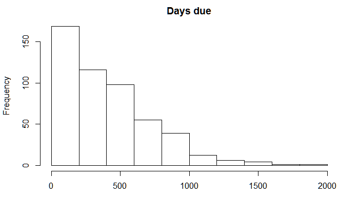

```r
#Histogram to explore days due
hist(df.cv[, c("DAYSDUE")],
     main = "Days due",
     xlab ="")
```

After data mining the aforementioned dataset, we decided to create a subset of COWS (number of dehornings larger than 1 with non-missing data for the following features: - Days since arrival at the farm at dehorning (proxy for age) - Quarter of dehorning (proxy for season) - Days since calving at dehorning - Calculated number of calvings - Quarter at calving - Number of dehornings - Total growth

```r
df.cv.cows <- na.omit(df.cv[!df.cv$N_DEHORNINGS == "1", c("CALC_ARRIVAL", "DH_QUARTER", "DIM_DEHORN", "CALC_PARITY", "C_QUARTER", "N_DEHORNINGS", "G_TOTAL")])
summary(df.cv.cows)
```

```
  CALC_ARRIVAL  DH_QUARTER   DIM_DEHORN     CALC_PARITY C_QUARTER
 Min.   : 252   1: 56      Min.   :   1.0   0:  0       1:169
 1st Qu.:1004   2:129      1st Qu.: 267.0   1:180       2: 83
 Median :1409   3: 94      Median : 462.0   2:139       3: 71
 Mean   :1398   4: 88      Mean   : 531.4   3: 43       4: 44
 3rd Qu.:1761              3rd Qu.: 717.0   4:  5
 Max.   :2636              Max.   :2070.0
 N_DEHORNINGS    G_TOTAL
 1:  0        Min.   : 0.00899
 2:243        1st Qu.: 2.16535
 3:111        Median : 2.62069
 4: 11        Mean   : 3.78089
 5:  2        3rd Qu.: 3.32012
              Max.   :60.06250
```

```r
#Set all number of dehornings larger then 3 equal to 3
df.cv.cows[df.cv.cows$N_DEHORNINGS == "4",]$N_DEHORNINGS <- "3"
df.cv.cows[df.cv.cows$N_DEHORNINGS == "5",]$N_DEHORNINGS <- "3"
```

Some histograms to increase interpretation of the current dataset

```r
op = par(mfrow=c(1, 2))
hist(df.cv.cows$G_TOTAL,
     main = "Total growth (g/day)",
     xlab ="")
hist(log10(df.cv.cows$G_TOTAL),
     main = "Log10(Total growth (g/day))",
     xlab = "")
```

[figure not shown]

```r
op = par(mfrow=c(1, 1))
```

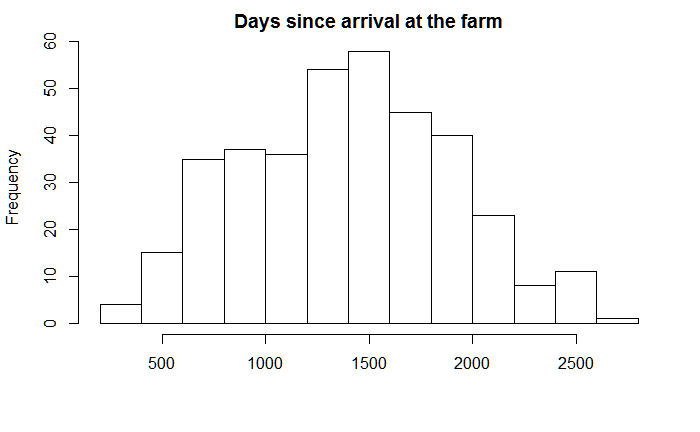

```r
hist(df.cv.cows$CALC_ARRIVAL,
     main = "Days since arrival at the farm",
     xlab ="")
op = par(mfrow=c(2, 2))
```

```r
hist(df.cv.cows[df.cv.cows$N_DEHORNINGS == "2",]$CALC_ARRIVAL,
     main = "Days since arrival at the farm",
     xlab ="Dehorning 2")
hist(df.cv.cows[df.cv.cows$N_DEHORNINGS == "3",]$CALC_ARRIVAL,
     main = "Days since arrival at the farm",
     xlab ="Dehorning 3")
```

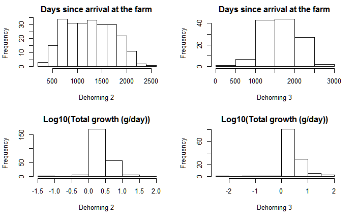

```r
hist(log10(df.cv.cows[df.cv.cows$N_DEHORNINGS == "2",]$G_TOTAL),
     main = "Log10(Total growth (g/day))",
     xlab ="Dehorning 2")
hist(log10(df.cv.cows[df.cv.cows$N_DEHORNINGS == "3",]$G_TOTAL),
     main = "Log10(Total growth (g/day))",
     xlab ="Dehorning 3")
```

### Model building

A [generalised linear model](https://en.wikipedia.org/wiki/Generalized_linear_model) is constructed, using [family=“log”](http://stats.stackexchange.com/questions/47840/linear-model-with-log-transformed-response-vs-generalized-linear-model-with-log) function.

First the baseline model is build, and next [univariate models](https://en.wikipedia.org/wiki/Univariate) are constructed for each of the variables.

```
Call:
glm(formula = G_TOTAL ~ 1, family = gaussian(link = "log"), data = df.cv.cows)

Deviance Residuals:
   Min      1Q  Median      3Q     Max
-3.772  -1.616  -1.160  -0.461  56.282

Coefficients:
            Estimate Std. Error t value Pr(>|t|)
(Intercept)  1.32996    0.07722   17.22   <2e-16 ***
---
Signif. codes:  0 ‘***’ 0.001 ‘**’ 0.01 ‘*’ 0.05 ‘.’ 0.1 ‘ ’ 1

(Dispersion parameter for gaussian family taken to be 31.28438)

    Null deviance: 11450  on 366  degrees of freedom
Residual deviance: 11450  on 366  degrees of freedom
AIC: 2308.1

Number of Fisher Scoring iterations: 7


Call:
glm(formula = G_TOTAL ~ N_DEHORNINGS, family = gaussian(link = "log"),
    data = df.cv.cows)

Deviance Residuals:
   Min      1Q  Median      3Q     Max
-4.776  -1.866  -0.975  -0.187  55.277

Coefficients:
              Estimate Std. Error t value Pr(>|t|)
(Intercept)     1.1843     0.1090  10.863   <2e-16 ***
N_DEHORNINGS3   0.3812     0.1508   2.527   0.0119 *
---
Signif. codes:  0 ‘***’ 0.001 ‘**’ 0.01 ‘*’ 0.05 ‘.’ 0.1 ‘ ’ 1

(Dispersion parameter for gaussian family taken to be 30.85296)

    Null deviance: 11450  on 366  degrees of freedom
```

[output cut: 115 more lines]

```
            Estimate Std. Error t value Pr(>|t|)
(Intercept)  1.29250    0.11837  10.919   <2e-16 ***
C_QUARTER2   0.19988    0.18204   1.098    0.273
C_QUARTER3  -0.02706    0.22186  -0.122    0.903
C_QUARTER4  -0.05751    0.27275  -0.211    0.833
---
Signif. codes:  0 ‘***’ 0.001 ‘**’ 0.01 ‘*’ 0.05 ‘.’ 0.1 ‘ ’ 1

(Dispersion parameter for gaussian family taken to be 31.40776)

    Null deviance: 11450  on 366  degrees of freedom
Residual deviance: 11401  on 363  degrees of freedom
AIC: 2312.5

Number of Fisher Scoring iterations: 7
```

### Model comparison

```r
## Comparison of basemodel and single variate models
anova(baseline, glm2, glm3, glm4, glm5, glm6, glm7,  test = "Chisq")
```

```
Analysis of Deviance Table

Model 1: G_TOTAL ~ 1
Model 2: G_TOTAL ~ N_DEHORNINGS
Model 3: G_TOTAL ~ CALC_ARRIVAL
Model 4: G_TOTAL ~ CALC_PARITY
Model 5: G_TOTAL ~ DIM_DEHORN
Model 6: G_TOTAL ~ DH_QUARTER
Model 7: G_TOTAL ~ C_QUARTER
  Resid. Df Resid. Dev Df Deviance Pr(>Chi)
1       366      11450
2       365      11261  1  188.843  0.01426 *
3       365      11231  0   29.894
4       363      11413  2 -181.823
5       365      11390 -2   23.647
6       363      11172  2  217.189  0.03162 *
7       363      11401  0 -228.457
---
Signif. codes:  0 ‘***’ 0.001 ‘**’ 0.01 ‘*’ 0.05 ‘.’ 0.1 ‘ ’ 1
```

```r
summary(glm8 <- glm(G_TOTAL~ N_DEHORNINGS + CALC_ARRIVAL + DH_QUARTER,
                    df.cv.cows,
                    family = gaussian(link="log")))
```

```
Call:
glm(formula = G_TOTAL ~ N_DEHORNINGS + CALC_ARRIVAL + DH_QUARTER,
    family = gaussian(link = "log"), data = df.cv.cows)

Deviance Residuals:
    Min       1Q   Median       3Q      Max
-11.161   -1.612   -0.325    0.799   50.129

Coefficients:
                Estimate Std. Error t value Pr(>|t|)
(Intercept)    2.4205722  0.1940466  12.474  < 2e-16 ***
N_DEHORNINGS3  0.8278346  0.1512858   5.472 8.34e-08 ***
CALC_ARRIVAL  -0.0009119  0.0001585  -5.755 1.85e-08 ***
DH_QUARTER2   -0.4567904  0.1810561  -2.523   0.0121 *
DH_QUARTER3   -0.3355781  0.2136329  -1.571   0.1171
DH_QUARTER4   -0.1197857  0.1750960  -0.684   0.4943
---
Signif. codes:  0 ‘***’ 0.001 ‘**’ 0.01 ‘*’ 0.05 ‘.’ 0.1 ‘ ’ 1

(Dispersion parameter for gaussian family taken to be 28.52446)

    Null deviance: 11450  on 366  degrees of freedom
Residual deviance: 10297  on 361  degrees of freedom
AIC: 2279.2

Number of Fisher Scoring iterations: 9
```

```r
anova(baseline, glm8, test = "Chisq")
```

```
Analysis of Deviance Table

Model 1: G_TOTAL ~ 1
Model 2: G_TOTAL ~ N_DEHORNINGS + CALC_ARRIVAL + DH_QUARTER
  Resid. Df Resid. Dev Df Deviance  Pr(>Chi)
1       366      11450
2       361      10297  5   1152.9 1.229e-07 ***
---
Signif. codes:  0 ‘***’ 0.001 ‘**’ 0.01 ‘*’ 0.05 ‘.’ 0.1 ‘ ’ 1
```

### Interaction

```r
summary(glm9 <- glm(G_TOTAL~ N_DEHORNINGS:CALC_ARRIVAL + DH_QUARTER,
                    df.cv.cows,
                    family = gaussian(link="log")))
```

```
Call:
glm(formula = G_TOTAL ~ N_DEHORNINGS:CALC_ARRIVAL + DH_QUARTER,
    family = gaussian(link = "log"), data = df.cv.cows)

Deviance Residuals:
   Min      1Q  Median      3Q     Max
-7.960  -1.702  -0.506   0.600  51.218

Coefficients:
                             Estimate Std. Error t value Pr(>|t|)
(Intercept)                 2.5520931  0.2030575  12.568  < 2e-16 ***
DH_QUARTER2                -0.4855800  0.1856152  -2.616  0.00927 **
DH_QUARTER3                -0.4630011  0.2214015  -2.091  0.03721 *
DH_QUARTER4                -0.1738372  0.1876728  -0.926  0.35492
N_DEHORNINGS2:CALC_ARRIVAL -0.0009053  0.0002141  -4.228 2.99e-05 ***
N_DEHORNINGS3:CALC_ARRIVAL -0.0004665  0.0001454  -3.208  0.00146 **
---
Signif. codes:  0 ‘***’ 0.001 ‘**’ 0.01 ‘*’ 0.05 ‘.’ 0.1 ‘ ’ 1

(Dispersion parameter for gaussian family taken to be 29.45858)

    Null deviance: 11450  on 366  degrees of freedom
Residual deviance: 10634  on 361  degrees of freedom
AIC: 2291

Number of Fisher Scoring iterations: 10
```

```r
anova(baseline, glm9, test = "Chisq")
```

```
Analysis of Deviance Table

Model 1: G_TOTAL ~ 1
Model 2: G_TOTAL ~ N_DEHORNINGS:CALC_ARRIVAL + DH_QUARTER
  Resid. Df Resid. Dev Df Deviance  Pr(>Chi)
1       366      11450
2       361      10634  5    815.9 4.173e-05 ***
---
Signif. codes:  0 ‘***’ 0.001 ‘**’ 0.01 ‘*’ 0.05 ‘.’ 0.1 ‘ ’ 1
```

To understand the effect of the interaction, an effects plot was created

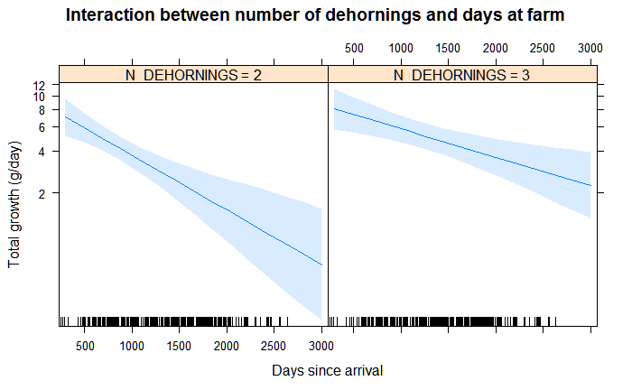

```r
plot(effect("N_DEHORNINGS:CALC_ARRIVAL",
            glm9,
            #xlevels=list(CALC_ARRIVAL=900:2000),
            multiline=TRUE),
     main = "Interaction between number of dehornings and days at farm",
     xlab = "Days since arrival",
     ylab = "Total growth (g/day)")
```

### Final model least square means

The [least square means](https://en.wikipedia.org/wiki/Least_squares) are constructed for the final variables.

This is the overal P-value per variables

```
Analysis of Deviance Table

Model: gaussian, link: log

Response: G_TOTAL

Terms added sequentially (first to last)

                          Df Deviance Resid. Df Resid. Dev  Pr(>Chi)
NULL                                        366      11450
DH_QUARTER                 3   277.75       363      11172 0.0241047 *
N_DEHORNINGS:CALC_ARRIVAL  2   538.15       361      10634 0.0001079 ***
---
Signif. codes:  0 ‘***’ 0.001 ‘**’ 0.01 ‘*’ 0.05 ‘.’ 0.1 ‘ ’ 1
```

Least square means, Tukey adjusted

```
NOTE: Results may be misleading due to involvement in interactions
```

```
$lsmeans
 N_DEHORNINGS response        SE df asymp.LCL asymp.UCL
 2            2.735232 0.4143694 NA  2.032558  3.680828
 3            5.050468 0.5283637 NA  4.114164  6.199856

Results are averaged over the levels of: DH_QUARTER
Confidence level used: 0.95
Intervals are back-transformed from the log scale

$contrasts
 contrast response.ratio        SE df z.ratio p.value
 2 - 3         0.5415799 0.1043803 NA  -3.182  0.0015

Results are averaged over the levels of: DH_QUARTER
Tests are performed on the log scale
```

```
NOTE: Results may be misleading due to involvement in interactions
```

```
 CALC_ARRIVAL response        SE df asymp.LCL asymp.UCL
     1397.586 3.716746 0.3253149 NA  3.130833  4.412308

Results are averaged over the levels of: N_DEHORNINGS, DH_QUARTER
Confidence level used: 0.95
Intervals are back-transformed from the log scale
$lsmeans
 DH_QUARTER response        SE df asymp.LCL asymp.UCL
 1          4.920712 0.6835420 NA  3.747887  6.460548
 2          3.027912 0.4495565 NA  2.263417  4.050623
 3          3.097056 0.5771455 NA  2.149439  4.462446
 4          4.135532 0.6008756 NA  3.110680  5.498034

Results are averaged over the levels of: N_DEHORNINGS
Confidence level used: 0.95
Intervals are back-transformed from the log scale

$contrasts
 contrast response.ratio        SE df z.ratio p.value
 1 - 2         1.6251172 0.3016464 NA   2.616  0.0441
 1 - 3         1.5888352 0.3517704 NA   2.091  0.1559
 1 - 4         1.1898619 0.2233048 NA   0.926  0.7908
 2 - 3         0.9776742 0.2273825 NA  -0.097  0.9997
 2 - 4         0.7321699 0.1474131 NA  -1.548  0.4085
 3 - 4         0.7488894 0.1721098 NA  -1.258  0.5897

Results are averaged over the levels of: N_DEHORNINGS
P value adjustment: tukey method for comparing a family of 4 estimates
Tests are performed on the log scale
```